# Experiencia 1: Captura de imagen en CPU

En esta primera parte de la experiencia se trabajará únicamente con **CPU**, utilizando **Python**, **OpenCV** y **Jupyter Notebook** sobre la plataforma **PYNQ-Z2**.

La imagen será capturada desde una **cámara Logitech Brio** conectada por **USB 2.0**. Durante esta fase también se medirán los tiempos básicos de ejecución, con el fin de conocer cuánto tarda cada etapa del flujo de captura.

La captura obtenida tendrá las siguientes características esperadas:

- formato de color: `BGR`
- tipo de dato: `uint8`
- resolución: `640 x 480`
- forma del arreglo: `(480, 640, 3)`

El objetivo de esta fase es aprender cómo adquirir una imagen desde software, visualizarla y registrar tiempos de ejecución antes de aplicar el proceso de resize.

## Paso 1. Importar las librerías necesarias

En este paso se importarán las librerías que se utilizarán durante la experiencia.

Se emplearán las siguientes herramientas:

- `cv2` de **OpenCV**: para abrir la cámara y capturar imágenes.
- `numpy`: para trabajar con arreglos.
- `matplotlib`: para mostrar la imagen en el notebook.
- `time`: para medir el tiempo de ejecución de cada etapa.

**Instrucción:** ejecute la siguiente celda.

```python
import cv2
import numpy as np
import matplotlib.pyplot as plt
import time
```

## Paso 2. Medir el tiempo de apertura de la cámara

En esta etapa se abrirá la cámara usando `cv2.VideoCapture(0)` y se medirá cuánto tarda esa operación.

**Qué se busca en este paso:** verificar que OpenCV puede acceder a la cámara y registrar el tiempo requerido para inicializar la captura.

**Instrucción:** ejecute la siguiente celda y observe el mensaje mostrado.

```python
t0_open = time.time()

cap = cv2.VideoCapture(0)

t1_open = time.time()
tiempo_apertura = t1_open - t0_open

if cap.isOpened():
    print("Camara abierta correctamente")
else:
    print("No se pudo abrir la camara")

print("Tiempo de apertura: {:.6f} segundos".format(tiempo_apertura))
```

```
Camara abierta correctamente
Tiempo de apertura: 0.815781 segundos
```

## Paso 3. Medir el tiempo de captura de la imagen

Ahora se capturará un frame desde la cámara y se medirá el tiempo necesario para realizar esta operación.

La función `cap.read()` devuelve:

- `ret`: indica si la captura fue exitosa.
- `frame`: contiene la imagen capturada.

**Qué se busca en este paso:** obtener una imagen válida desde la cámara y conocer el tiempo de captura.

**Instrucción:** ejecute la siguiente celda.

```python
t0_capture = time.time()

ret, frame = cap.read()

t1_capture = time.time()
tiempo_captura = t1_capture - t0_capture

if ret:
    print("Imagen capturada correctamente")
else:
    print("Error al capturar la imagen")

print("Tiempo de captura: {:.6f} segundos".format(tiempo_captura))
```

```
Imagen capturada correctamente
Tiempo de captura: 1.127892 segundos
```

## Paso 4. Liberar la cámara

Después de capturar la imagen, se debe liberar la cámara.

**Qué se busca en este paso:** cerrar correctamente el acceso al dispositivo y dejar libre el recurso para futuras capturas.

**Instrucción:** ejecute la siguiente celda.

```python
cap.release()
print("Camara liberada")
```

```
Camara liberada
```

## Paso 5. Verificar las propiedades de la imagen capturada

En esta etapa se revisarán las características principales de la imagen capturada.

Se espera obtener:

- tipo de dato `uint8`
- dimensiones `(480, 640, 3)`

Esto corresponde a una imagen de `640 x 480` en formato `BGR`.

**Qué se busca en este paso:** comprobar que la imagen coincide con las condiciones de entrada del laboratorio.

**Instrucción:** ejecute la siguiente celda.

```python
print("Tipo de dato:", frame.dtype)
print("Dimensiones:", frame.shape)
```

```
Tipo de dato: uint8
Dimensiones: (480, 640, 3)
```

## Paso 6. Medir el tiempo de conversión y visualización

OpenCV entrega la imagen en formato `BGR`, mientras que `matplotlib` utiliza `RGB` para mostrar correctamente los colores.

Por ello, en esta etapa se convertirá la imagen de `BGR` a `RGB` y se medirá el tiempo asociado a esta operación.

**Qué se busca en este paso:** visualizar correctamente la imagen capturada y registrar el costo temporal de la conversión.

**Instrucción:** ejecute la siguiente celda.

[figure not shown]

```
Tiempo de conversion BGR a RGB: 0.005990 segundos
```

```python
t0_display = time.time()

frame_rgb = cv2.cvtColor(frame, cv2.COLOR_BGR2RGB)

t1_display = time.time()
tiempo_conversion = t1_display - t0_display

plt.figure(figsize=(8,6))
plt.imshow(frame_rgb)
plt.title("Imagen capturada")
plt.axis("off")
plt.show()

print("Tiempo de conversion BGR a RGB: {:.6f} segundos".format(tiempo_conversion))
```

## Paso 7. Guardar la imagen capturada

La imagen capturada se guardará en un archivo para poder reutilizarla en las siguientes etapas del laboratorio.

**Qué se busca en este paso:** conservar una copia de la entrada que luego será utilizada en el resize en CPU y en la versión acelerada por hardware.

**Instrucción:** ejecute la siguiente celda.

```python
t0_save = time.time()

cv2.imwrite("captura_brio.png", frame)

t1_save = time.time()
tiempo_guardado = t1_save - t0_save

print("Imagen guardada como captura_brio.png")
print("Tiempo de guardado: {:.6f} segundos".format(tiempo_guardado))
```

```
Imagen guardada como captura_brio.png
Tiempo de guardado: 0.162986 segundos
```

## Paso 8. Mostrar el tiempo total del flujo

Finalmente, se calculará el tiempo total aproximado de las operaciones principales ejecutadas en esta fase.

**Qué se busca en este paso:** tener una primera referencia temporal del flujo de captura en CPU antes de pasar al procesamiento posterior.

**Instrucción:** ejecute la siguiente celda.

```python
tiempo_total = tiempo_apertura + tiempo_captura + tiempo_conversion + tiempo_guardado

print("Resumen de tiempos")
print("Tiempo de apertura       : {:.6f} s".format(tiempo_apertura))
print("Tiempo de captura        : {:.6f} s".format(tiempo_captura))
print("Tiempo de conversion RGB : {:.6f} s".format(tiempo_conversion))
print("Tiempo de guardado       : {:.6f} s".format(tiempo_guardado))
print("Tiempo total aproximado  : {:.6f} s".format(tiempo_total))
```

[output not shown]

## Paso 9. Interpretación de resultados

En esta fase se ejecutó el flujo básico de captura de imagen en **CPU**, utilizando Python y OpenCV sobre la PYNQ-Z2.

Además de capturar y visualizar la imagen, se registraron tiempos de ejecución de varias etapas del proceso:

- apertura de cámara,
- captura del frame,
- conversión de color,
- y guardado de la imagen.

Estos tiempos sirven como referencia inicial para comprender el costo del procesamiento en software y preparar una comparación posterior con etapas aceleradas por hardware.

# Etapa de resize en CPU

Una vez capturada la imagen, el siguiente paso es aplicar una operación de **reescalado** para reducir su tamaño desde `640 x 480` hasta `320 x 240`.

En esta fase el procesamiento se realiza únicamente en **CPU**, utilizando la librería **OpenCV**. Esto permitirá obtener una referencia de funcionamiento y tiempo de ejecución antes de implementar la versión acelerada en hardware.

El objetivo es que el estudiante observe:

- cómo se realiza el resize desde software,
- cómo cambian las dimensiones de la imagen,
- cuánto tiempo tarda esta operación,
- y cómo se compara visualmente la imagen original con la imagen reescalada.

## Paso 10. Verificar el tamaño original de la imagen

Antes de aplicar el resize, conviene confirmar nuevamente las dimensiones de la imagen capturada.

**Qué se busca en este paso:** verificar que la imagen de entrada corresponde a la resolución esperada de `640 x 480`.

**Instrucción:** ejecute la siguiente celda.

```python
print("Dimensiones originales:", frame.shape)
```

```
Dimensiones originales: (480, 640, 3)
```

## Paso 11. Aplicar el resize en CPU

En este paso se realizará el reescalado de la imagen usando la función `cv2.resize()` de **OpenCV**.

La nueva resolución será:

- ancho: `320`
- alto: `240`

La instrucción utilizada será:

`cv2.resize(frame, (320, 240))`

Es importante notar que OpenCV recibe el tamaño en el orden:

`(ancho, alto)`

**Qué se busca en este paso:** generar una nueva imagen reducida en tamaño, manteniendo la estructura de tres canales de color.

**Instrucción:** ejecute la siguiente celda.

```python
t0_resize = time.time()

frame_resized = cv2.resize(frame, (320, 240))

t1_resize = time.time()
tiempo_resize_cpu = t1_resize - t0_resize

print("Resize ejecutado correctamente")
print("Tiempo de resize en CPU: {:.6f} segundos".format(tiempo_resize_cpu))
```

```
Resize ejecutado correctamente
Tiempo de resize en CPU: 0.021543 segundos
```

## Paso 12. Verificar las dimensiones de la imagen reescalada

Después de ejecutar el resize, se debe comprobar que la nueva imagen tiene el tamaño esperado.

Para esta experiencia, la salida debe corresponder a:

- resolución `320 x 240`
- forma `(240, 320, 3)`

**Qué se busca en este paso:** confirmar que la operación de resize produjo la salida correcta.

**Instrucción:** ejecute la siguiente celda.

```python
print("Dimensiones reescaladas:", frame_resized.shape)
print("Tipo de dato:", frame_resized.dtype)
```

```
Dimensiones reescaladas: (240, 320, 3)
Tipo de dato: uint8
```

## Paso 13. Visualizar la imagen reescalada

En esta etapa se mostrará la imagen resultante del resize.

Como la imagen original fue capturada en formato `BGR`, se debe convertir también la imagen reescalada a `RGB` antes de visualizarla con `matplotlib`.

**Qué se busca en este paso:** observar visualmente la salida del resize en CPU.

**Instrucción:** ejecute la siguiente celda.

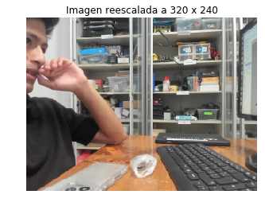

```python
frame_resized_rgb = cv2.cvtColor(frame_resized, cv2.COLOR_BGR2RGB)

plt.figure(figsize=(6,4))
plt.imshow(frame_resized_rgb)
plt.title("Imagen reescalada a 320 x 240")
plt.axis("off")
plt.show()
```

## Paso 14. Comparación visual proporcional entre la imagen original y la imagen reescalada

Cuando se usan subgráficos (`subplot`), `matplotlib` suele mostrar ambas imágenes ocupando espacios similares dentro de la figura. Por esta razón, aunque las resoluciones sean diferentes, visualmente pueden parecer del mismo tamaño.

Para observar la diferencia proporcional real, en este paso se mostrará cada imagen manteniendo una relación más cercana a sus dimensiones originales. De esta forma, la imagen de `640 x 480` se verá más grande que la imagen reescalada de `320 x 240`.

**Qué se busca en este paso:** apreciar visualmente que la imagen reescalada tiene la mitad del ancho y la mitad del alto respecto a la imagen original.

**Instrucción:** ejecute la siguiente celda.

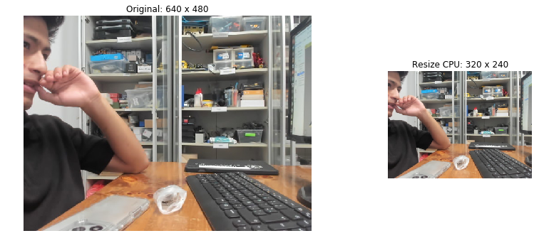

```python
fig = plt.figure(figsize=(12, 6))

# Imagen original más grande
ax1 = fig.add_axes([0.05, 0.15, 0.50, 0.70])
ax1.imshow(frame_rgb)
ax1.set_title("Original: 640 x 480")
ax1.axis("off")

# Imagen reescalada más pequeña y proporcional
ax2 = fig.add_axes([0.65, 0.32, 0.25, 0.35])
ax2.imshow(frame_resized_rgb)
ax2.set_title("Resize CPU: 320 x 240")
ax2.axis("off")

plt.show()
```

## Paso 15. Guardar la imagen reescalada

La imagen de salida también puede guardarse para utilizarla en comparaciones posteriores o como evidencia del resultado obtenido.

**Qué se busca en este paso:** almacenar la salida generada por el resize en CPU.

**Instrucción:** ejecute la siguiente celda.

```python
t0_save_resize = time.time()

cv2.imwrite("captura_resize_cpu_320x240.png", frame_resized)

t1_save_resize = time.time()
tiempo_guardado_resize = t1_save_resize - t0_save_resize

print("Imagen guardada como captura_resize_cpu_320x240.png")
print("Tiempo de guardado: {:.6f} segundos".format(tiempo_guardado_resize))
```

```
Imagen guardada como captura_resize_cpu_320x240.png
Tiempo de guardado: 0.083548 segundos
```

## Paso 16. Mostrar resumen de tiempos de esta etapa

Además del tiempo de captura medido previamente, ahora interesa registrar el costo temporal de la operación de resize en CPU.

**Qué se busca en este paso:** identificar cuánto tarda la reducción de resolución en software y dejar esta medición como referencia para la etapa con aceleración hardware.

**Instrucción:** ejecute la siguiente celda.

```python
print("Resumen de tiempos de la etapa de resize en CPU")
print("Tiempo de resize en CPU : {:.6f} s".format(tiempo_resize_cpu))
print("Tiempo de guardado      : {:.6f} s".format(tiempo_guardado_resize))
```

```
Resumen de tiempos de la etapa de resize en CPU
Tiempo de resize en CPU : 0.021543 s
Tiempo de guardado      : 0.083548 s
```

## Paso 17. Interpretación de resultados

En esta etapa se realizó el reescalado de la imagen desde `640 x 480` hasta `320 x 240` utilizando únicamente **CPU** y la función `cv2.resize()` de **OpenCV**.

Con este procedimiento se pudo verificar que:

- la operación de resize puede ejecutarse completamente desde software,
- la imagen de salida mantiene el formato esperado,
- las nuevas dimensiones corresponden a `(240, 320, 3)`,
- y es posible medir el tiempo de ejecución de esta etapa.

Este resultado será utilizado como referencia base para comparar posteriormente el comportamiento de una implementación acelerada por hardware en la FPGA.